# Interval coverage

Jarad Niemi

2023-03-07

R code

```r
library("tidyverse"); theme_set(theme_bw())
set.seed(20230305)
```

# Confidence intervals

## Examples

### Normal

#### Known variance

Let $Y_i\stackrel{ind}{\sim} N(\mu,\sigma^2)$ with $\sigma$ known. A 100(1-a)% confidence interval for $\mu$ is
$$\overline{y} \pm z_{1-a/2} \sigma / \sqrt{n}$$
where

- $n$ is the sample size,
- $\overline{y}$ is the sample mean, and
- $z_{1-a/2}$ is the *z critical value* such that $1-a/2 = P(Z < z_{1-a/2})$ where $Z$ is a standard normal.

**Note:** The variance is known here and thus you can use a z critical value.

For example

```r
a <- 0.05
mu <- 0
sigma <- 1

y <- rnorm(10, mean = mu, sd = sigma)
ybar <- mean(y)
n <- length(y)
z <- qnorm(1-a/2)

ybar + c(-1,1) * z * sigma / sqrt(n)
```

```
## [1] -0.9775914  0.2619987
```

#### Unknown variance

Let $Y_i\stackrel{ind}{\sim} N(\mu,\sigma^2)$ with $\mu$ and $\sigma^2$ both unknown. A 100(1-a)% confidence interval for $\mu$ is
$$\overline{y} \pm t_{n-1,1-a/2} s / \sqrt{n}$$
where

- $n$ is the sample size,
- $\overline{y}$ is the sample mean,
- $s$ is the sample standard deviation, and
- $t_{n-1,1-a/2}$ is the *t critical value* such that $1-a/2 = P(T_{n-1} < t_{n-1,1-a/2})$ where $T_{n-1}$ is a student $T$ distribution with $n-1$ degrees of freedom.

For example

```r
s <- sd(y)
t <- qt(1-a/2, df = n-1)

ybar + c(-1,1) * t * s / sqrt(n)
```

```
## [1] -1.1173711  0.4017784
```

As $n\to\infty$, $t_{n-1,1-a/2} \to z_{1-a/2}$ and $s^2 \to \sigma^2$. (That is, $s^2$ is a *consistent* estimator for $\sigma^2$.) Thus, for large sample sizes, an *approximate* 100(1-a)% confidence interval for $\mu$ is
$$\overline{y} \pm z_{1-a/2} s / \sqrt{n}$$
where we have replaced the t critical value with a z critical value.

For example

```r
ybar + c(-1,1) * z * s / sqrt(n)
```

```
## [1] -1.0159024  0.3003096
```

**Note:** The t interval is an exact confidence interval while this interval is an approximate confidence interval.

### Binomial

#### Large sample

Let $X\sim Bin(n,\theta)$. An approximate 100(1-a)% confidence interval for $\theta$ is
$$\hat\theta \pm z_{1-a/2} \sqrt{\frac{\hat\theta(1-\hat\theta)}{n}}$$
where $\hat\theta = x/n$.

This is an approximate confidence interval because it is constructed based on the Central Limit Theorem (CLT) which states that, for large enough sample size,
$$\hat\theta \stackrel{\cdot}{\sim} N\left( \theta,
\frac{\hat\theta(1-\hat\theta)}{n} \right).$$

For example

```r
p <- 0.5
n <- 30

x <- rbinom(1, size = n, prob = p)

theta_hat <- x/n

theta_hat + c(-1,1) * z * sqrt(theta_hat*(1-theta_hat)/n)
```

```
## [1] 0.1942261 0.5391072
```

#### binom.test()

R actually does not implement this interval in any of its base R functions. Instead, it provides better confidence intervals.

For example,

```r
binom.test(x, n)$conf.int
```

```
## [1] 0.1992986 0.5614402
## attr(,"conf.level")
## [1] 0.95
```

This interval is based on [the Clopper-Pearson interval](https://en.wikipedia.org/wiki/Binomial_proportion_confidence_interval#Clopper%E2%80%93Pearson_interval). This interval finds all the values for theta that do not reject a hypothesis test (when those values are set as the null value) and constructing the interval based on those values. These confidence intervals are *exact*.

#### prop.test()

Here are some improved *approximate* confidence intervals.

```r
prop.test(x, n)$conf.int
```

```
## [1] 0.2054281 0.5609198
## attr(,"conf.level")
## [1] 0.95
```

```r
prop.test(x, n, correct = FALSE)$conf.int
```

```
## [1] 0.2187392 0.5448644
## attr(,"conf.level")
## [1] 0.95
```

These intervals are based on [Wilson’s score interval](https://en.wikipedia.org/wiki/Binomial_proportion_confidence_interval#Wilson_score_interval) with and without [continuity correction](https://en.wikipedia.org/wiki/Binomial_proportion_confidence_interval#Wilson_score_interval_with_continuity_correction). There are all approximate as they are based on a better asymptotic approximation.

There are many more [approximate confidence intervals for a binomial probability](https://en.wikipedia.org/wiki/Binomial_proportion_confidence_interval).

## Interpretation

So what is a confidence interval anyway? When we have a $100(1-a)$% confidence interval, what does the $100(1-a)$% mean? When the interval is approximate, what does that mean?

An exact $100(1-a)$% confidence interval means that, across different realizations of your data, the probability that the interval will contain the truth is at least $1-a$.

An approximate $100(1-a)$% confidence interval means that as the sample size tends to infinity, across different realizations of your data, the probability that the interval will contain the truth converges to at least $1-a$.

The key to both of these definitions is that it is talking about what happens for different realizations of your data.

# Monte Carlo

Remember that to understand the uncertainty in our Monte Carlo estimate we can utilize the CLT.

```r
create_ci <- function(x, a = 0.05) {
  theta_hat <- mean(x)
  n <- length(x)

  theta_hat + c(-1,1) * qnorm(1-a/2) * sqrt(theta_hat*(1-theta_hat)/n)
}
```

## Normal

### Known variance

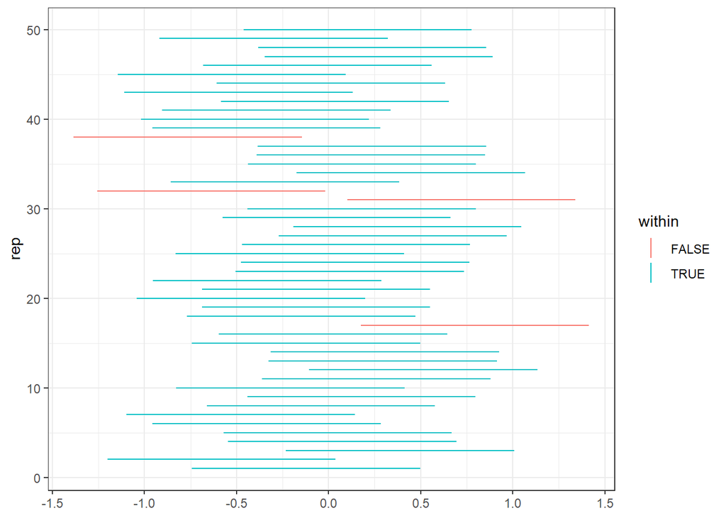

```r
a <- 0.05
n <- 10
mu <- 0
sigma <- 1

z <- qnorm(1-a/2)

d <- expand.grid(rep = 1:1e3,
            n = 1:n) %>%
  mutate(
    y = rnorm(n(),
              mean = mu,
              sd = sigma)
  ) %>%
  group_by(rep) %>%
  summarize(
    n = n(),
    ybar = mean(y),
    lcl = ybar - z * sigma / sqrt(n),
    ucl = ybar + z * sigma / sqrt(n),
    .groups = "drop"
  ) %>%
  mutate(
    within = lcl <= mu & mu <= ucl
  )

ggplot(d %>% filter(rep <= 50),
       aes(x = rep, ymin = lcl, ymax = ucl, color = within)) +
  geom_linerange() +
  coord_flip()
```

```r
d %>%
  pull(within) %>%
  create_ci()
```

```
## [1] 0.9387509 0.9652491
```

### Unknown variance

```r
t <- qt(1-a/2, df = n-1)

expand.grid(rep = 1:1e3,
            n = 1:n) %>%
  mutate(
    y = rnorm(n(),
              mean = mu,
              sd = sigma)
  ) %>%
  group_by(rep) %>%
  summarize(
    n = n(),
    ybar = mean(y),
    s = sd(y),
    lcl = ybar - t * s / sqrt(n),
    ucl = ybar + t * s / sqrt(n),
    .groups = "drop"
  ) %>%
  mutate(
    within = lcl <= mu & mu <= ucl
  ) %>%
  pull(within) %>%
  create_ci()
```

```
## [1] 0.9455676 0.9704324
```

### Approximate

```r
expand.grid(rep = 1:1e3,
            n = 1:n) %>%
  mutate(
    y = rnorm(n(),
              mean = mu,
              sd = sigma)
  ) %>%
  group_by(rep) %>%
  summarize(
    n = n(),
    ybar = mean(y),
    s = sd(y),
    lcl = ybar - z * s / sqrt(n),
    ucl = ybar + z * s / sqrt(n),
    .groups = "drop"
  ) %>%
  mutate(
    within = lcl <= mu & mu <= ucl
  ) %>%
  pull(within) %>%
  create_ci()
```

```
## [1] 0.8911741 0.9268259
```

## Binomial

### CLT

```r
n <- 30
p <- 0.5

data.frame(
  x = rbinom(1e3, size = n, prob = p)
) %>%
  mutate(
    theta_hat = x/n,

    lcl = theta_hat - z * sqrt(theta_hat*(1-theta_hat)/n),
    ucl = theta_hat + z * sqrt(theta_hat*(1-theta_hat)/n),
    within = lcl <= p & p <= ucl
  ) %>%
  pull(within) %>%
  create_ci()
```

```
## [1] 0.9455676 0.9704324
```

### Exact

```r
data.frame(
  x = rbinom(1e3, size = n, prob = p)
) %>%
  rowwise() %>%
  mutate(
    lcl = binom.test(x, n)$conf.int[1],
    ucl = binom.test(x, n)$conf.int[2],
    within = lcl <= p & p <= ucl
  ) %>%
  pull(within) %>%
  create_ci()
```

```
## [1] 0.9594271 0.9805729
```

### Wilson’s score interval

```r
a <- 0.05
n <- 30
p <- 0.5

data.frame(
  x = rbinom(1e3, size = n, prob = p)
) %>%
  rowwise() %>%
  mutate(
    lcl = prop.test(x, n, correct = FALSE)$conf.int[1],
    ucl = prop.test(x, n, correct = FALSE)$conf.int[2],
    within = lcl <= p & p <= ucl
  ) %>%
  pull(within) %>%
  create_ci()
```

```
## [1] 0.9524538 0.9755462
```

### Wilson’s score interval with continuity correction

```r
data.frame(
  x = rbinom(1e3, size = n, prob = p)
) %>%
  rowwise() %>%
  mutate(
    lcl = prop.test(x, n, correct = TRUE)$conf.int[1],
    ucl = prop.test(x, n, correct = TRUE)$conf.int[2],
    within = lcl <= p & p <= ucl
  ) %>%
  pull(within) %>%
  create_ci()
```

```
## [1] 0.9376206 0.9643794
```